# Learning Patterns

*Supervised Tasks and Adaptation*

Noé Durandard (noe.durandard@psl.eu)

Introduction to NLP — MSc. DH EdC-PSL

November 11, 2025

# 1 Recap

### 1.0.1 The Language Modeling Problem

**Language Model**

A Language Model (LM) estimates the probability of pieces of text. Given a sequence of text $w_{1},w_{2},\cdots,w_{S}$, it answers the question:

**What is $P(w_{1},w_{2},\cdots,w_{S})$?**

How to compute $P$?

- Count-based (count): $n$-gram
- Neural method (learn): Transformer
  - Masked Language Modeling (encoder-only, BERT)
  - Causal Language Modeling (decoder-only, GPT)

$\to$ encode:

- gramaticality
- semantic plausability
- stylistic consistency
- knowledge (?)

### 1.0.2 Document Representation & Unsupervised Tasks

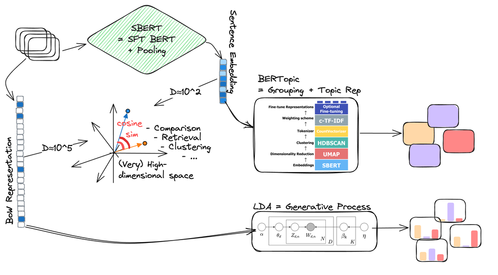

# 2 Supervised Learning

## 2.1 Introduction

### 2.1.1 Supervised Learning

**Goal**

Learn patterns that map *inputs* (texts, sentences, etc.) to *outputs* (labels, categories, values) based on *annotated examples*.

*What you need?*

- **Training data**: documents annotated with *labels* (‘ground-truth’)
- A **model** that can make predictions
- A **loss function** that measures the model performance
- An **optimisation process** that nudge the model towards lower loss

$\to$ The model will *‘learn’* from examples (and corrections), improving its predictions through training.

### 2.1.2 Supervised Learning NLP Tasks

- **Classification**: Assign a *label* to an entire text or sentence
  - *Sentiment analysis* (positive / negative reviews)
  - *Topic classification* (political / cultural / literary texts)
  - *Spam detection*, *author identification*, *genre prediction*
- **Regression**: Predict a *continuous value*
  - Predicting a *readability score* or *publication year* from a text
- **Sequence Labelling**: Assign a label to *tokens* in a sequence (classification)
  - *Named Entity Recognition (NER)*: tagging names of people, places, organizations
  - *Part-of-Speech tagging*
- **Question Answering (QA)**
  - The model identifies an *answer span* in a text based on a given question
- **Other tasks**
  - *Text summarization*, *machine translation*, *paraphrase detection*  
    (still supervised — but outputs are more complex)

### 2.1.3 Idealised Supervised NLP Workflow

1. Define the task
2. Collect and annotate data
3. Prepare the data
4. Train the model
5. Evaluate and interpret results
6. Analyze outputs and errors
7. (Deploy?)

## 2.2 Main Approaches in modern NLP

### 2.2.1 Representation + standard ML

**Approach**

Use *precomputed text embeddings* as numerical representations of texts, then train a *standard ML model* on top.

1. **Embed** text
   - BoW, TF-IDF, Word2Vec, Sentence-BERT, …
2. **Train** a standard ML model on the labelled embeddings
   - Logistic Regression, SVM, Random Forest, MLP, …
3. **Predict** in the *embedding space*
   - new document $\to$ frozen embedding model $\to$ trained ML model $\to$ prediction

#### 2.2.1.1 Rep+ML Overview

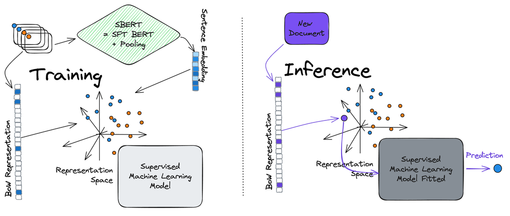

### 2.2.2 Supervised Fine-tuning

**Approach**

Adapt a *pretrained transformer model* end-to-end to a specific downstream task by *updating its parameters* through training on labeled data.

1. Choose a **pretrained model** & add a **task-specific head**
   - pre-trained LM already knows language structure (remember LM lecture)
   - add a task-specific (classification, regression, …) head on top of LM
2. **Fine-tune** the model
   - update the model’s weights during training thanks to the labeled data
3. **Predict** directly from text
   - text $\to$ fine-tuned LM $\to$ prediction

#### 2.2.2.1 SFT Overview

[figure not shown]

*Two steps of BERT development (extracted and modified from (Alammar 2018)).*

## 2.3 Summary

### 2.3.1 Takeaways

| **Representation + ML** | **Fine-Tuning** |
| --- | --- |
| Freeze embeddings, train small model | Adapt all model weights |
| Fast, lightweight | Higher compute cost |
| Works with few labels | Needs more data |
| Easier to interpret & reuse | Task-specific, less interpretable |
| Strong for exploratory DH tasks | Best for high-performance NLP |

**Key point**

**Representation + ML:** modular, interpretable, resource-light

**Fine-Tuning:** powerful, task-adaptive, but resource-intensive

**Keep in mind**

- *‘Ground-truth’* might not be absolute
- Model choice reflects task and data
- Tune with intention
- Interpret critically

# 3 Classification

## 3.1 What is a classification task?

### 3.1.1 Description

**Goal**

Assign each input text to one of a set of predefined categories or classes.

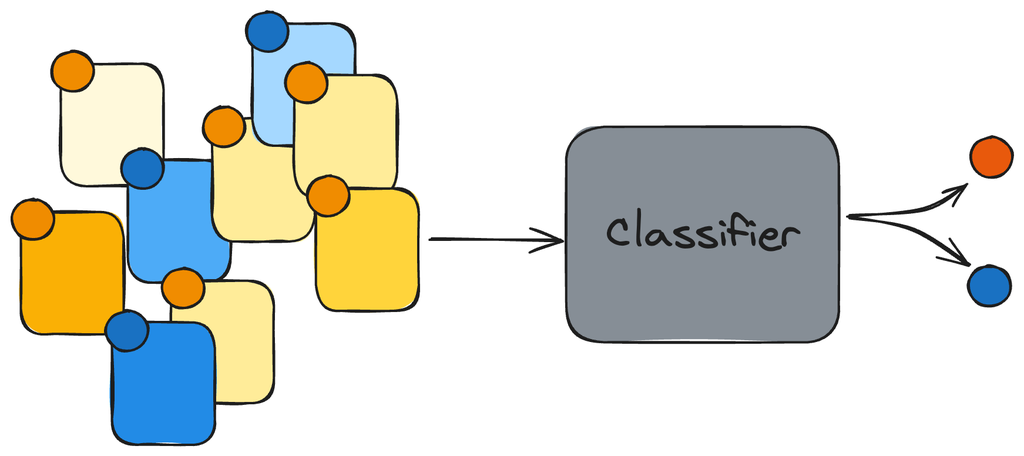

### 3.1.2 Overview

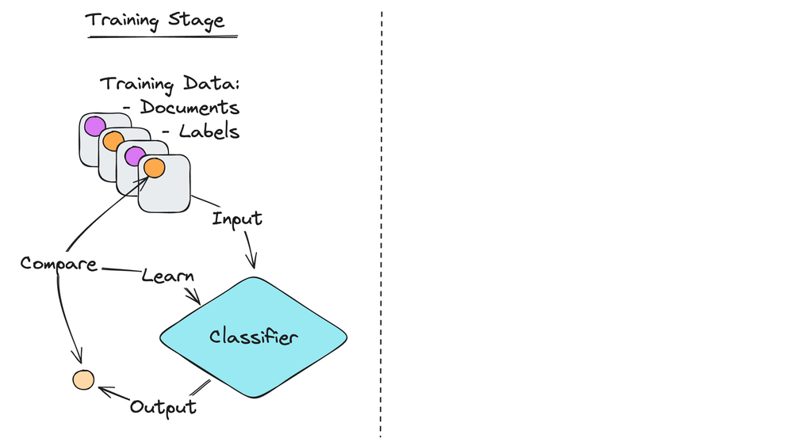

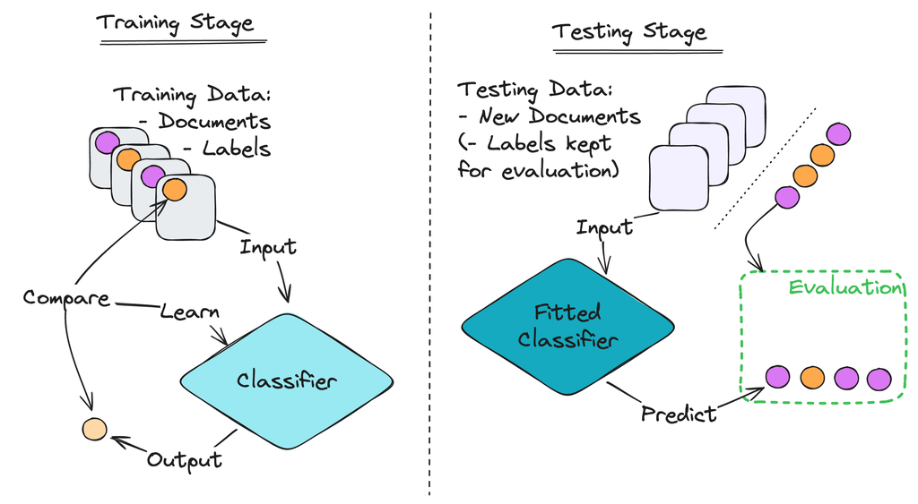

## 3.2 The Confusion Matrix & Performance Metrics

### 3.2.1 Confusion Matrix

**Definition**

Matrix where each cell counts examples by how the predictions compare to the ground truth.

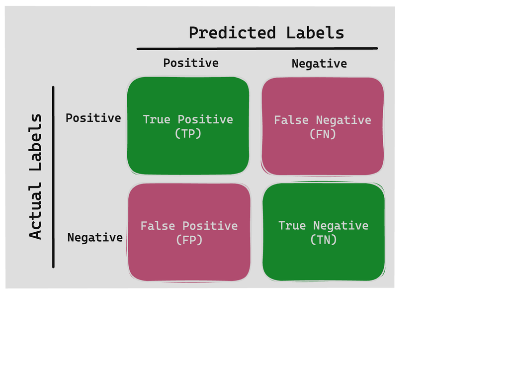

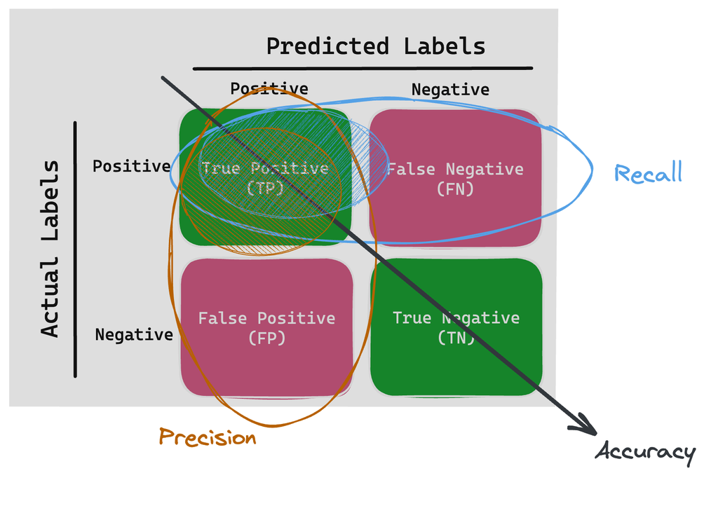

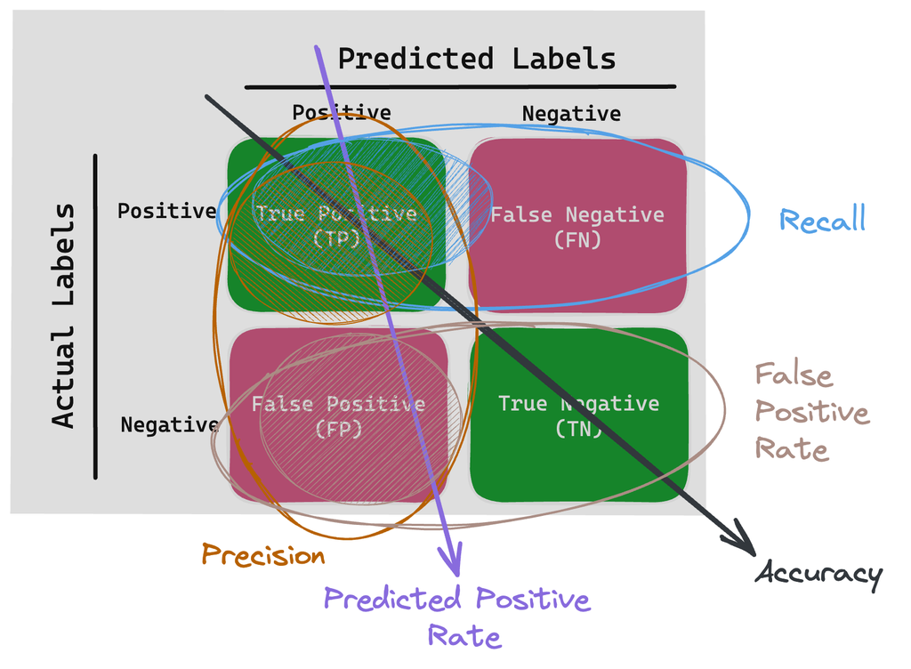

### 3.2.2 Performance Metrics

| Metric | Formula | Interpretation |
| --- | --- | --- |
| **Accuracy** | $\frac{TP + TN}{TP + TN + FP + FN}$ | › Overall proportion of correct predictions |
| **Positive Predicted Value** | $\frac{TP}{TP + FP}$ | › How accurate the positive predictions are (=precision) |
| **True Positive Rate** | $\frac{TP}{TP + FN}$ | › Coverage of actual positive sample (=recall) |
| **F1-score** | $\frac{2\times\mathrm{PPV}\times\mathrm{TPR}}{\mathrm{PPV}+\mathrm{TPR}}$ | › Harmonic mean of precision and recall |
| **False Positive Rate** | $\frac{FP}{FP+TN}$ | › Proportion of incorrect positive predictions |
| **Predicted Positive Rate** | $\frac{TP+FP}{TP+TN+FP+FN}$ | › Proportion of samples predicted as positive |

### 3.2.3 Quick Example

- Accuracy
  - (2+4)/(2+1+2+4) = 6/9 $\approx$ 0.66
- Precision
  - 2/(2+2) = 2/4 = 0.5
- Recall
  - 2/(2+1) = 2/3 $\approx$ 0.66
- F1-score
  - $\frac{2\times\mathrm{precision}\times\mathrm{recall}}{\mathrm{precision}+\mathrm{recall}}$
- …

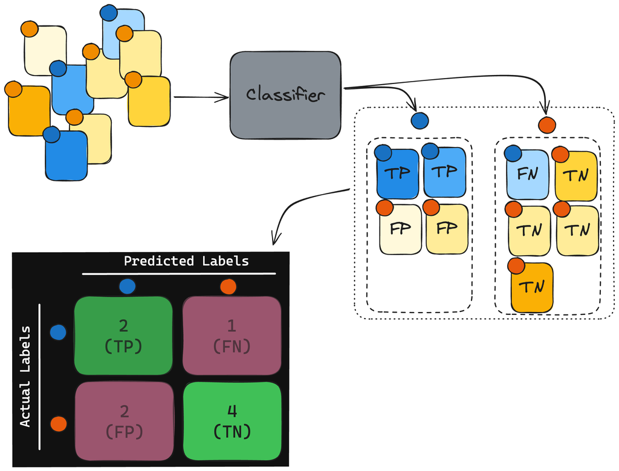

## 3.3 *Is that enough?*

### 3.3.1 Some examples…

… reinforcing structural discriminations, through:

- Reported Bias & Runaway Feedback Loops
  - Minorities targeting in predictive justice (Angwin et al. 2016); predictive policing (Lum and Isaac 2016; Rotaru et al. 2022)
- Latent Bias & Sampling Bias
  - Racial healthcare disparities (Obermeyer et al. 2019)
  - Gender bias in credit scoring (Telford 2019) and recruitment practices (Dastin 2022)
  - Classist biases in welfare systems (QdN 2023)
- …

*(a) Number of days with targeted policing for drug crimes in areas flagged by PredPol analysis of Oakland police data. (b) Targeted policing for drug crimes, by race. (c) Estimated drug use by race (extracted from (Lum and Isaac 2016)).*

[figure not shown]

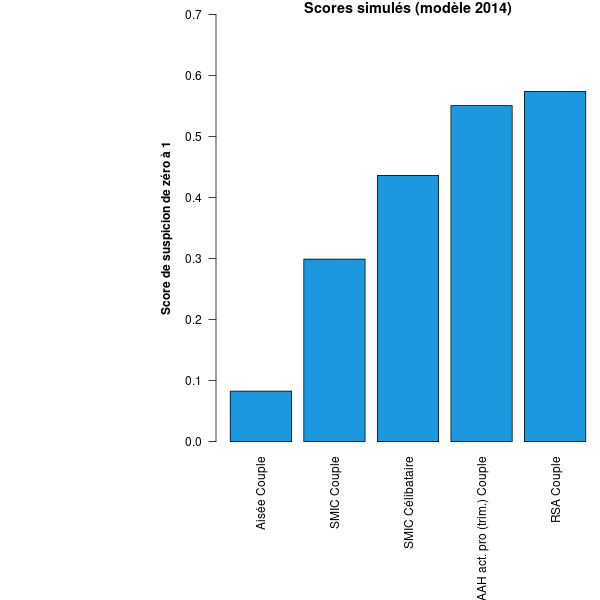

*CAF’s suspicion score (extracted from (QdN 2023)).*

## 3.4 Fairness Metrics

### 3.4.1 Conceptual Overview

Three core concepts (Barocas, Hardt, and Narayanan 2023):

1. **Independence** — predictions are statistically independent of sensitive attributes
   - e.g., same positive rate for all groups
2. **Separation** — error rates are similar across groups, conditional on the true label
   - e.g., same false-positive / false-negative rates for each group
3. **Sufficiency** — predictions are equally reliable across groups
   - e.g., for a given predicted probability, the actual correctness is the same

### 3.4.2 Underlying idea

**Fairness across groups**

The model should perform similarly across groups.

$\to$ compute performance metrics for differnt groups:  
let $p$ refer to privileged group and $n$ to non-privileged group:

$m_\mathrm{p}=\mathrm{score}(\mathrm{TP}_\mathrm{p},\mathrm{FP}_\mathrm{p},\mathrm{TN}_\mathrm{p},\mathrm{FN}_\mathrm{p}),\quad m_\mathrm{n}=\mathrm{score}(\mathrm{TP}_\mathrm{n},\mathrm{FP}_\mathrm{n},\mathrm{TN}_\mathrm{n},\mathrm{FN}_\mathrm{n})$

$\to$ compare them with a ratio. A “fair” model should ensure (RoT: $\epsilon\approx0.8$):

$$\epsilon \leq \frac{m_\mathrm{n}}{m_\mathrm{p}} \leq 1/\epsilon$$

### 3.4.3 Practical Measures of Fairness

| Name | Metric | Concept | Interpretation (Wiśniewski and Biecek 2022) |
| --- | --- | --- | --- |
| **Statistical Parity** | **PPR** | Independence (equivalent) | whether both groups have equal likelihood of being *predicted as positive* |
| **Equal Opportunity** | **TPR** | Separation (relaxation) | likelihood of *correctly* recognising a *positive* is equal regardless of group |
| **Predictive Equality** | **FPR** | Separation (relaxation) | likelihood of *incorrectly* classifying a *negative* as *positive* is equal regardless of group |
| **Predictive Parity** | **PPV** | Sufficiency (relaxation) | whether *positive* are equally reliable across groups |
| **Accuracy Difference** | **ACC** | — | whether the model *performance* is *consistent* across groups |

### [💡Reminder: *based on per-group performance*]

| Metric | Formula | Interpretation |
| --- | --- | --- |
| **Predicted Positive Rate (PPR)** | $\frac{TP+FP}{TP+TN+FP+FN}$ | › Proportion of samples predicted as positive |
| **True Positive Rate (TPR)** | $\frac{TP}{TP + FN}$ | › Coverage of actual positive sample (=recall) |
| **False Positive Rate (FPR)** | $\frac{FP}{FP+TN}$ | › Proportion of incorrect positive predictions |
| **Positive Predicted Value** | $\frac{TP}{TP + FP}$ | › How accurate the positive predictions are (=precision) |
| **Accuracy** | $\frac{TP + TN}{TP + TN + FP + FN}$ | › Overall proportion of correct predictions |

## 3.5 Key Message

- Strong Model $\nRightarrow$ Fair Model
- (Fair Model $\nRightarrow$ Strong Model)

# 4 [Hands-on](https://github.com/d-noe/NLP_DH_PSL_Fall2025/tree/main/code#code_week3)

## 4.1 Hands-On Challenge

[interactive chart not shown]

## References

Alammar, Jay. 2018. “The Illustrated Bert, Elmo, and Co. (How NLP Cracked Transfer Learning).” *Visualizing Machine Learning One Concept at a Time.* https://jalammar.github.io/illustrated-bert/.

Angwin, Julia, Jeff Larson, Surya Mattu, and Lauren Kirchner. 2016. “Machine Bias.” *Propublica*. https://www.propublica.org/article/machine-bias-risk-assessments-in-criminal-sentencing.

Barocas, Solon, Moritz Hardt, and Arvind Narayanan. 2023. *Fairness and Machine Learning: Limitations and Opportunities*. MIT Press. https://fairmlbook.org.

Dastin, Jeffrey. 2022. “Amazon Scraps Secret AI Recruiting Tool That Showed Bias Against Women.” In *Ethics of Data and Analytics*, 296–99. Auerbach Publications.

Lum, Kristian, and William Isaac. 2016. “To Predict and Serve?” *Significance* 13 (5): 14–19. https://doi.org/https://doi.org/10.1111/j.1740-9713.2016.00960.x.

Obermeyer, Ziad, Brian Powers, Christine Vogeli, and Sendhil Mullainathan. 2019. “Dissecting Racial Bias in an Algorithm Used to Manage the Health of Populations.” *Science* 366 (6464): 447–53. https://doi.org/10.1126/science.aax2342.

QdN. 2023. “Scoring of Welfare Beneficiaries: The Indecency of CAF’s Algorithm Now Undeniable.” *La Quadrature Du Net*. https://www.laquadrature.net/en/2023/11/27/scoring-of-welfare-beneficiaries-the-indecency-of-cafs-algorithm-now-undeniable/.

Rotaru, Victor, Yi Huang, Timmy Li, James Evans, and Ishanu Chattopadhyay. 2022. “Event-Level Prediction of Urban Crime Reveals a Signature of Enforcement Bias in US Cities.” *Nature Human Behaviour* 6 (8): 1056–68. https://doi.org/10.1038/s41562-022-01372-0.

Telford, Taylor. 2019. “Apple Card Algorithm Sparks Gender Bias Allegations Against Goldman Sachs.” *Washington Post* 11.

Wiśniewski, Jakub, and Przemysław Biecek. 2022. “Fairmodels: A Flexible Tool for Bias Detection, Visualization, and Mitigation.” https://arxiv.org/abs/2104.00507.

Learning Patterns

[figure not shown]